# Homework 8

4/6/2025

Kaustubh Duddala

[Github](https://github.com/kaustubhduddala/StatisticsAndDataScience/tree/main/SDS%20315/Homework%208)

## Question 1

#### A

The estimated creatinine clearance for a 55-year-old individual is about 113.72 ml/minute. This was calculated by building a linear regression model using the creatinine.csv data, extracting the intercept and the coefficient for age, and then applying the formula: `creatclear = intercept + (age coefficient × 55)`. This allows us to estimate the expected clearance rate for any given age.

#### B

The estimated value of B₁ (the age coefficient or slope) from our linear model is about -0.62. This means that for each additional year of age, the expected creatinine clearance decreases by about 0.62 mL/minute.

#### C

For the 40-year-old, the observed creatinine clearance is about 11.98 mL/minute higher than what the model predicts. For the 60-year-old, the observed clearance is 1.38 mL/minute above the expected value. This suggests that the 40-year-old (with a clearance rate of 135) is relatively healthier for their age compared to the 60-year-old (with a rate of 112). These residuals were calculated by subtracting the model’s predicted value from the observed value for each individual: for the 40-year-old, `135 - (intercept + age coefficient × 40) = 12`.

## Question 2

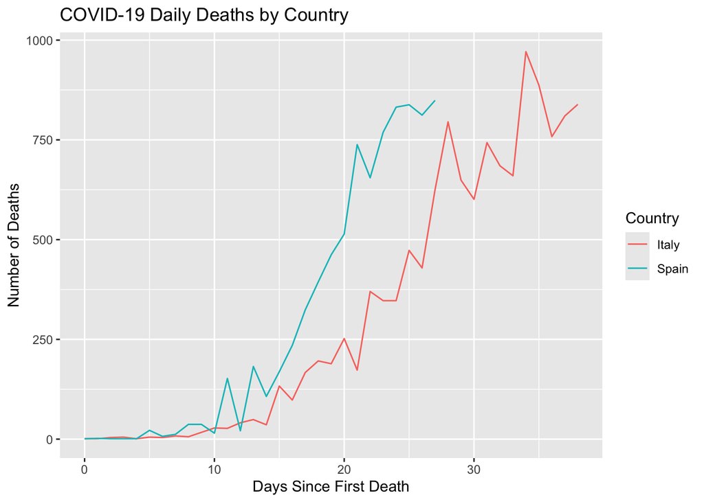

For both Italy and Spain, we modeled daily COVID-19 deaths using an exponential growth model:  
`log(deaths) = intercept + growth_rate × days_since_first_death`  
The growth rate is the slope, and doubling time is log(2) divided by the growth rate, and 10,000 bootstrap samples are used to estimate 95% confidence intervals.

Italy: - Growth rate: 0.18 - Doubling time: 3.78 days - 95% CI for growth rate: (0.16, 0.21) - 95% CI for doubling time: (3.33, 4.35)

Spain: - Growth rate: 0.28 - Doubling time: 2.51 days - 95% CI for growth rate: (0.23, 0.32) - 95% CI for doubling time: (2.18, 2.96)

Spain’s deaths grew faster and doubled more quickly than Italy’s during this period.

## Question 3

the estimated price elasticity of demand for milk was found by fitting a linear regression to the log-transformed sales and price data, using the model: `log(sales) = intercept + elasticity × log(price)` The elasticity coefficient (the slope) quantifies the percentage change in sales for a 1% change in price. To assess the uncertainty of the estimate, 10,000 bootstrap samples were used to calculate a 95% confidence interval.

Estimated elasticity: -1.62

95% Confidence Interval: (-1.77, -1.46)

This means that a 1% increase in the price of milk is associated with an estimated 1.62% decrease in the quantity of milk sold.